# Risk Factor Analysis

## Outcome Variable

**Outcome Variable:** wasted

## Predictor Variables

**Intervention Variable:** birthwt

**Adjustment Set:**

- arm
- sex
- W_mage
- meducyrs
- feducyrs
- hhwealth_quart
- vagbrth
- W_nrooms
- brthmon
- W_parity
- impfloor
- impsan
- safeh20
- delta_W_mage
- delta_meducyrs
- delta_feducyrs
- delta_hhwealth_quart
- delta_vagbrth
- delta_W_nrooms
- delta_brthmon
- delta_W_parity
- delta_impfloor
- delta_impsan
- delta_safeh20

## Stratifying Variables

The analysis was stratified on these variable(s):

- agecat
- studyid
- country

## Data Summary

| agecat | studyid | country | birthwt | wasted | n_cell | n |
| --- | --- | --- | --- | --- | --- | --- |
| Birth | ki0047075b-MAL-ED | BANGLADESH | Normal or high birthweight | 0 | 177 | 241 |
| Birth | ki0047075b-MAL-ED | BANGLADESH | Normal or high birthweight | 1 | 25 | 241 |
| Birth | ki0047075b-MAL-ED | BANGLADESH | Low birth weight | 0 | 24 | 241 |
| Birth | ki0047075b-MAL-ED | BANGLADESH | Low birth weight | 1 | 15 | 241 |
| Birth | ki0047075b-MAL-ED | BRAZIL | Normal or high birthweight | 0 | 174 | 183 |
| Birth | ki0047075b-MAL-ED | BRAZIL | Normal or high birthweight | 1 | 5 | 183 |
| Birth | ki0047075b-MAL-ED | BRAZIL | Low birth weight | 0 | 3 | 183 |
| Birth | ki0047075b-MAL-ED | BRAZIL | Low birth weight | 1 | 1 | 183 |
| Birth | ki0047075b-MAL-ED | INDIA | Normal or high birthweight | 0 | 152 | 203 |
| Birth | ki0047075b-MAL-ED | INDIA | Normal or high birthweight | 1 | 19 | 203 |
| Birth | ki0047075b-MAL-ED | INDIA | Low birth weight | 0 | 18 | 203 |
| Birth | ki0047075b-MAL-ED | INDIA | Low birth weight | 1 | 14 | 203 |
| Birth | ki0047075b-MAL-ED | NEPAL | Normal or high birthweight | 0 | 142 | 168 |
| Birth | ki0047075b-MAL-ED | NEPAL | Normal or high birthweight | 1 | 13 | 168 |
| Birth | ki0047075b-MAL-ED | NEPAL | Low birth weight | 0 | 6 | 168 |
| Birth | ki0047075b-MAL-ED | NEPAL | Low birth weight | 1 | 7 | 168 |
| Birth | ki0047075b-MAL-ED | PERU | Normal or high birthweight | 0 | 260 | 279 |
| Birth | ki0047075b-MAL-ED | PERU | Normal or high birthweight | 1 | 5 | 279 |
| Birth | ki0047075b-MAL-ED | PERU | Low birth weight | 0 | 13 | 279 |
| Birth | ki0047075b-MAL-ED | PERU | Low birth weight | 1 | 1 | 279 |
| Birth | ki0047075b-MAL-ED | SOUTH AFRICA | Normal or high birthweight | 0 | 231 | 258 |
| Birth | ki0047075b-MAL-ED | SOUTH AFRICA | Normal or high birthweight | 1 | 13 | 258 |
| Birth | ki0047075b-MAL-ED | SOUTH AFRICA | Low birth weight | 0 | 9 | 258 |
| Birth | ki0047075b-MAL-ED | SOUTH AFRICA | Low birth weight | 1 | 5 | 258 |
| Birth | ki0047075b-MAL-ED | TANZANIA, UNITED REPUBLIC OF | Normal or high birthweight | 0 | 112 | 118 |
| Birth | ki0047075b-MAL-ED | TANZANIA, UNITED REPUBLIC OF | Normal or high birthweight | 1 | 1 | 118 |
| Birth | ki0047075b-MAL-ED | TANZANIA, UNITED REPUBLIC OF | Low birth weight | 0 | 4 | 118 |
| Birth | ki0047075b-MAL-ED | TANZANIA, UNITED REPUBLIC OF | Low birth weight | 1 | 1 | 118 |
| Birth | ki1000108-CMC-V-BCS-2002 | INDIA | Normal or high birthweight | 0 | 70 | 88 |
| Birth | ki1000108-CMC-V-BCS-2002 | INDIA | Normal or high birthweight | 1 | 9 | 88 |

[output cut: 286 more lines]

The following strata were considered:

- agecat: 24 months, studyid: ki0047075b-MAL-ED, country: BANGLADESH
- agecat: 24 months, studyid: ki0047075b-MAL-ED, country: BRAZIL
- agecat: 24 months, studyid: ki0047075b-MAL-ED, country: INDIA
- agecat: 24 months, studyid: ki0047075b-MAL-ED, country: NEPAL
- agecat: 24 months, studyid: ki0047075b-MAL-ED, country: PERU
- agecat: 24 months, studyid: ki0047075b-MAL-ED, country: SOUTH AFRICA
- agecat: 24 months, studyid: ki0047075b-MAL-ED, country: TANZANIA, UNITED REPUBLIC OF
- agecat: 24 months, studyid: ki1000108-CMC-V-BCS-2002, country: INDIA
- agecat: 24 months, studyid: ki1000108-IRC, country: INDIA
- agecat: 24 months, studyid: ki1017093-NIH-Birth, country: BANGLADESH
- agecat: 24 months, studyid: ki1017093b-PROVIDE, country: BANGLADESH
- agecat: 24 months, studyid: ki1017093c-NIH-Crypto, country: BANGLADESH
- agecat: 24 months, studyid: ki1066203-TanzaniaChild2, country: TANZANIA, UNITED REPUBLIC OF
- agecat: 24 months, studyid: ki1101329-Keneba, country: GAMBIA
- agecat: 24 months, studyid: ki1114097-CMIN, country: BANGLADESH
- agecat: 24 months, studyid: ki1114097-CMIN, country: PERU
- agecat: 24 months, studyid: ki1114097-CONTENT, country: PERU
- agecat: 24 months, studyid: ki1119695-PROBIT, country: BELARUS
- agecat: 24 months, studyid: ki1126311-ZVITAMBO, country: ZIMBABWE
- agecat: 24 months, studyid: ki1135781-COHORTS, country: GUATEMALA
- agecat: 24 months, studyid: ki1135781-COHORTS, country: INDIA
- agecat: 24 months, studyid: ki1135781-COHORTS, country: PHILIPPINES
- agecat: 24 months, studyid: kiGH5241-JiVitA-3, country: BANGLADESH
- agecat: 24 months, studyid: kiGH5241-JiVitA-4, country: BANGLADESH
- agecat: 6 months, studyid: ki0047075b-MAL-ED, country: BANGLADESH
- agecat: 6 months, studyid: ki0047075b-MAL-ED, country: BRAZIL
- agecat: 6 months, studyid: ki0047075b-MAL-ED, country: INDIA
- agecat: 6 months, studyid: ki0047075b-MAL-ED, country: NEPAL
- agecat: 6 months, studyid: ki0047075b-MAL-ED, country: PERU
- agecat: 6 months, studyid: ki0047075b-MAL-ED, country: SOUTH AFRICA
- agecat: 6 months, studyid: ki0047075b-MAL-ED, country: TANZANIA, UNITED REPUBLIC OF
- agecat: 6 months, studyid: ki1000108-CMC-V-BCS-2002, country: INDIA
- agecat: 6 months, studyid: ki1000108-IRC, country: INDIA
- agecat: 6 months, studyid: ki1000109-EE, country: PAKISTAN
- agecat: 6 months, studyid: ki1000109-ResPak, country: PAKISTAN
- agecat: 6 months, studyid: ki1000304b-SAS-CompFeed, country: INDIA
- agecat: 6 months, studyid: ki1017093-NIH-Birth, country: BANGLADESH
- agecat: 6 months, studyid: ki1017093b-PROVIDE, country: BANGLADESH
- agecat: 6 months, studyid: ki1017093c-NIH-Crypto, country: BANGLADESH
- agecat: 6 months, studyid: ki1066203-TanzaniaChild2, country: TANZANIA, UNITED REPUBLIC OF
- agecat: 6 months, studyid: ki1101329-Keneba, country: GAMBIA
- agecat: 6 months, studyid: ki1114097-CMIN, country: BANGLADESH
- agecat: 6 months, studyid: ki1114097-CMIN, country: BRAZIL
- agecat: 6 months, studyid: ki1114097-CMIN, country: GUINEA-BISSAU
- agecat: 6 months, studyid: ki1114097-CMIN, country: PERU
- agecat: 6 months, studyid: ki1114097-CONTENT, country: PERU
- agecat: 6 months, studyid: ki1119695-PROBIT, country: BELARUS
- agecat: 6 months, studyid: ki1126311-ZVITAMBO, country: ZIMBABWE
- agecat: 6 months, studyid: ki1135781-COHORTS, country: GUATEMALA
- agecat: 6 months, studyid: ki1135781-COHORTS, country: INDIA
- agecat: 6 months, studyid: ki1135781-COHORTS, country: PHILIPPINES
- agecat: 6 months, studyid: kiGH5241-JiVitA-3, country: BANGLADESH
- agecat: 6 months, studyid: kiGH5241-JiVitA-4, country: BANGLADESH
- agecat: Birth, studyid: ki0047075b-MAL-ED, country: BANGLADESH
- agecat: Birth, studyid: ki0047075b-MAL-ED, country: BRAZIL
- agecat: Birth, studyid: ki0047075b-MAL-ED, country: INDIA
- agecat: Birth, studyid: ki0047075b-MAL-ED, country: NEPAL
- agecat: Birth, studyid: ki0047075b-MAL-ED, country: PERU
- agecat: Birth, studyid: ki0047075b-MAL-ED, country: SOUTH AFRICA
- agecat: Birth, studyid: ki0047075b-MAL-ED, country: TANZANIA, UNITED REPUBLIC OF
- agecat: Birth, studyid: ki1000108-CMC-V-BCS-2002, country: INDIA
- agecat: Birth, studyid: ki1000108-IRC, country: INDIA
- agecat: Birth, studyid: ki1000109-EE, country: PAKISTAN
- agecat: Birth, studyid: ki1000109-ResPak, country: PAKISTAN
- agecat: Birth, studyid: ki1000304b-SAS-CompFeed, country: INDIA
- agecat: Birth, studyid: ki1017093-NIH-Birth, country: BANGLADESH
- agecat: Birth, studyid: ki1017093c-NIH-Crypto, country: BANGLADESH
- agecat: Birth, studyid: ki1101329-Keneba, country: GAMBIA
- agecat: Birth, studyid: ki1114097-CMIN, country: BANGLADESH
- agecat: Birth, studyid: ki1114097-CMIN, country: BRAZIL
- agecat: Birth, studyid: ki1114097-CMIN, country: PERU
- agecat: Birth, studyid: ki1114097-CONTENT, country: PERU
- agecat: Birth, studyid: ki1119695-PROBIT, country: BELARUS
- agecat: Birth, studyid: ki1126311-ZVITAMBO, country: ZIMBABWE
- agecat: Birth, studyid: ki1135781-COHORTS, country: GUATEMALA
- agecat: Birth, studyid: ki1135781-COHORTS, country: INDIA
- agecat: Birth, studyid: ki1135781-COHORTS, country: PHILIPPINES
- agecat: Birth, studyid: kiGH5241-JiVitA-3, country: BANGLADESH
- agecat: Birth, studyid: kiGH5241-JiVitA-4, country: BANGLADESH

### Dropped Strata

Some strata were dropped due to rare outcomes:

- agecat: Birth, studyid: ki0047075b-MAL-ED, country: BRAZIL
- agecat: Birth, studyid: ki0047075b-MAL-ED, country: PERU
- agecat: Birth, studyid: ki0047075b-MAL-ED, country: TANZANIA, UNITED REPUBLIC OF
- agecat: Birth, studyid: ki1000108-CMC-V-BCS-2002, country: INDIA
- agecat: Birth, studyid: ki1000109-EE, country: PAKISTAN
- agecat: Birth, studyid: ki1000109-ResPak, country: PAKISTAN
- agecat: Birth, studyid: ki1000304b-SAS-CompFeed, country: INDIA
- agecat: Birth, studyid: ki1017093-NIH-Birth, country: BANGLADESH
- agecat: Birth, studyid: ki1017093c-NIH-Crypto, country: BANGLADESH
- agecat: Birth, studyid: ki1114097-CMIN, country: BANGLADESH
- agecat: Birth, studyid: ki1114097-CMIN, country: BRAZIL
- agecat: Birth, studyid: ki1114097-CMIN, country: PERU
- agecat: Birth, studyid: ki1114097-CONTENT, country: PERU
- agecat: Birth, studyid: ki1119695-PROBIT, country: BELARUS
- agecat: 6 months, studyid: ki0047075b-MAL-ED, country: BANGLADESH
- agecat: 6 months, studyid: ki0047075b-MAL-ED, country: BRAZIL
- agecat: 6 months, studyid: ki0047075b-MAL-ED, country: INDIA
- agecat: 6 months, studyid: ki0047075b-MAL-ED, country: NEPAL
- agecat: 6 months, studyid: ki0047075b-MAL-ED, country: PERU
- agecat: 6 months, studyid: ki0047075b-MAL-ED, country: SOUTH AFRICA
- agecat: 6 months, studyid: ki0047075b-MAL-ED, country: TANZANIA, UNITED REPUBLIC OF
- agecat: 6 months, studyid: ki1000109-ResPak, country: PAKISTAN
- agecat: 6 months, studyid: ki1066203-TanzaniaChild2, country: TANZANIA, UNITED REPUBLIC OF
- agecat: 6 months, studyid: ki1114097-CMIN, country: BANGLADESH
- agecat: 6 months, studyid: ki1114097-CMIN, country: BRAZIL
- agecat: 6 months, studyid: ki1114097-CMIN, country: GUINEA-BISSAU
- agecat: 6 months, studyid: ki1114097-CMIN, country: PERU
- agecat: 6 months, studyid: ki1114097-CONTENT, country: PERU
- agecat: 6 months, studyid: ki1119695-PROBIT, country: BELARUS
- agecat: 6 months, studyid: ki1135781-COHORTS, country: GUATEMALA
- agecat: 24 months, studyid: ki0047075b-MAL-ED, country: BANGLADESH
- agecat: 24 months, studyid: ki0047075b-MAL-ED, country: BRAZIL
- agecat: 24 months, studyid: ki0047075b-MAL-ED, country: NEPAL
- agecat: 24 months, studyid: ki0047075b-MAL-ED, country: PERU
- agecat: 24 months, studyid: ki0047075b-MAL-ED, country: SOUTH AFRICA
- agecat: 24 months, studyid: ki0047075b-MAL-ED, country: TANZANIA, UNITED REPUBLIC OF
- agecat: 24 months, studyid: ki1066203-TanzaniaChild2, country: TANZANIA, UNITED REPUBLIC OF
- agecat: 24 months, studyid: ki1114097-CMIN, country: BANGLADESH
- agecat: 24 months, studyid: ki1114097-CMIN, country: PERU
- agecat: 24 months, studyid: ki1114097-CONTENT, country: PERU
- agecat: 24 months, studyid: ki1119695-PROBIT, country: BELARUS

## Methods Detail

We’re interested in the causal parameters $E[Y_a]$ for all values of $a \in \mathcal{A}$. These parameters represent the mean outcome if, possibly contrary to fact, we intervened to set all units to have $A=a$. Under the randomization and positivity assumptions, these are identified by the statistical parameters $\psi_a=E_W[E_{Y|A,W}(Y|A=a,W)]$. In addition, we’re interested in the mean of $Y$, $E[Y]$ under no intervention (the observed mean). We will estimate these parameters by using SuperLearner to fit the relevant likelihood factors – $E_{Y|A,W}(Y|A=a,W)$ and $p(A=a|W)$, and then updating our likelihood fit using a joint TMLE.

For unadjusted analyses ($W=\{\}$), initial likelihoods were estimated using Lrnr_glm to estimate the simple $E(Y|A)$ and Lrnr_mean to estimate $p(A)$. For adjusted analyses, a small library containing Lrnr_glmnet, Lrnr_xgboost, and Lrnr_mean was used.

Having estimated these parameters, we will then use the delta method to estimate relative risks and attributable risks relative to a prespecified baseline level of $A$.

# Results Detail

## Results Plots

[figure not shown]

[figure not shown]

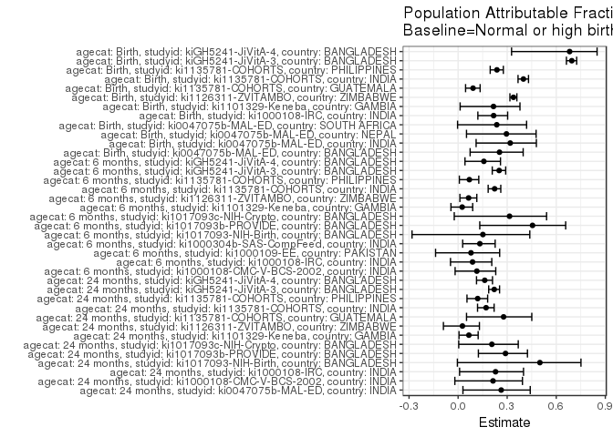

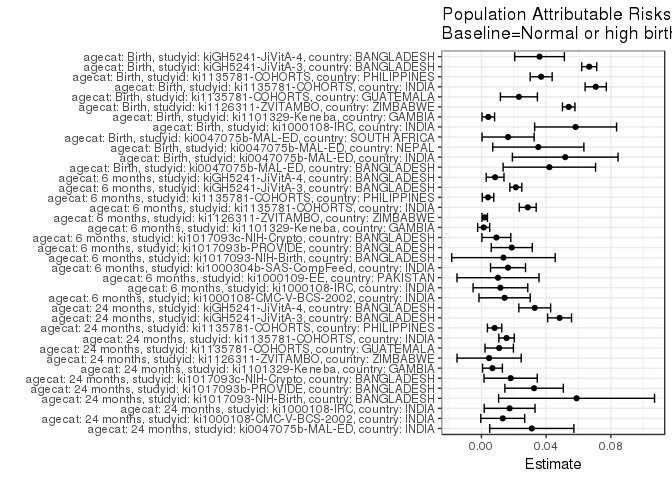

## Results Table

### Parameter: TSM

| agecat | studyid | country | intervention_level | baseline_level | estimate | ci_lower | ci_upper |
| --- | --- | --- | --- | --- | --- | --- | --- |
| Birth | ki0047075b-MAL-ED | BANGLADESH | Normal or high birthweight | NA | 0.1239856 | 0.0785497 | 0.1694216 |
| Birth | ki0047075b-MAL-ED | BANGLADESH | Low birth weight | NA | 0.3852747 | 0.2352192 | 0.5353302 |
| Birth | ki0047075b-MAL-ED | INDIA | Normal or high birthweight | NA | 0.1107537 | 0.0635399 | 0.1579675 |
| Birth | ki0047075b-MAL-ED | INDIA | Low birth weight | NA | 0.4422277 | 0.2695680 | 0.6148873 |
| Birth | ki0047075b-MAL-ED | NEPAL | Normal or high birthweight | NA | 0.0838710 | 0.0401024 | 0.1276396 |
| Birth | ki0047075b-MAL-ED | NEPAL | Low birth weight | NA | 0.5384615 | 0.2666586 | 0.8102645 |
| Birth | ki0047075b-MAL-ED | SOUTH AFRICA | Normal or high birthweight | NA | 0.0532787 | 0.0250439 | 0.0815135 |
| Birth | ki0047075b-MAL-ED | SOUTH AFRICA | Low birth weight | NA | 0.3571429 | 0.1056616 | 0.6086241 |
| Birth | ki1000108-IRC | INDIA | Normal or high birthweight | NA | 0.2099911 | 0.1636367 | 0.2563455 |
| Birth | ki1000108-IRC | INDIA | Low birth weight | NA | 0.6355981 | 0.4987327 | 0.7724635 |
| Birth | ki1101329-Keneba | GAMBIA | Normal or high birthweight | NA | 0.0154202 | 0.0087121 | 0.0221283 |
| Birth | ki1101329-Keneba | GAMBIA | Low birth weight | NA | 0.0634921 | 0.0208998 | 0.1060843 |
| Birth | ki1126311-ZVITAMBO | ZIMBABWE | Normal or high birthweight | NA | 0.1055263 | 0.0999462 | 0.1111064 |
| Birth | ki1126311-ZVITAMBO | ZIMBABWE | Low birth weight | NA | 0.6331966 | 0.6082224 | 0.6581707 |
| Birth | ki1135781-COHORTS | GUATEMALA | Normal or high birthweight | NA | 0.2307914 | 0.1996304 | 0.2619524 |
| Birth | ki1135781-COHORTS | GUATEMALA | Low birth weight | NA | 0.5625198 | 0.4347154 | 0.6903243 |
| Birth | ki1135781-COHORTS | INDIA | Normal or high birthweight | NA | 0.1063148 | 0.0979482 | 0.1146813 |
| Birth | ki1135781-COHORTS | INDIA | Low birth weight | NA | 0.5424148 | 0.5146432 | 0.5701863 |
| Birth | ki1135781-COHORTS | PHILIPPINES | Normal or high birthweight | NA | 0.1186367 | 0.1064399 | 0.1308334 |
| Birth | ki1135781-COHORTS | PHILIPPINES | Low birth weight | NA | 0.6470799 | 0.5942992 | 0.6998607 |
| Birth | kiGH5241-JiVitA-3 | BANGLADESH | Normal or high birthweight | NA | 0.0292346 | 0.0258126 | 0.0326565 |
| Birth | kiGH5241-JiVitA-3 | BANGLADESH | Low birth weight | NA | 0.2498636 | 0.2365624 | 0.2631647 |
| Birth | kiGH5241-JiVitA-4 | BANGLADESH | Normal or high birthweight | NA | 0.0167690 | 0.0013672 | 0.0321707 |
| Birth | kiGH5241-JiVitA-4 | BANGLADESH | Low birth weight | NA | 0.1895226 | 0.1240795 | 0.2549657 |
| 6 months | ki1000108-CMC-V-BCS-2002 | INDIA | Normal or high birthweight | NA | 0.1106783 | 0.0765163 | 0.1448404 |
| 6 months | ki1000108-CMC-V-BCS-2002 | INDIA | Low birth weight | NA | 0.2335109 | 0.1075448 | 0.3594769 |
| 6 months | ki1000108-IRC | INDIA | Normal or high birthweight | NA | 0.1212569 | 0.0864089 | 0.1561049 |
| 6 months | ki1000108-IRC | INDIA | Low birth weight | NA | 0.1915002 | 0.0979978 | 0.2850026 |
| 6 months | ki1000109-EE | PAKISTAN | Normal or high birthweight | NA | 0.1200667 | 0.0788007 | 0.1613327 |
| 6 months | ki1000109-EE | PAKISTAN | Low birth weight | NA | 0.1100709 | 0.0568273 | 0.1633144 |
| 6 months | ki1000304b-SAS-CompFeed | INDIA | Normal or high birthweight | NA | 0.1074112 | 0.0773464 | 0.1374760 |
| 6 months | ki1000304b-SAS-CompFeed | INDIA | Low birth weight | NA | 0.1859402 | 0.1592488 | 0.2126316 |
| 6 months | ki1017093-NIH-Birth | BANGLADESH | Normal or high birthweight | NA | 0.0762712 | 0.0282445 | 0.1242979 |
| 6 months | ki1017093-NIH-Birth | BANGLADESH | Low birth weight | NA | 0.1166667 | 0.0352091 | 0.1981243 |
| 6 months | ki1017093b-PROVIDE | BANGLADESH | Normal or high birthweight | NA | 0.0224738 | 0.0086978 | 0.0362497 |
| 6 months | ki1017093b-PROVIDE | BANGLADESH | Low birth weight | NA | 0.1083451 | 0.0608792 | 0.1558109 |
| 6 months | ki1017093c-NIH-Crypto | BANGLADESH | Normal or high birthweight | NA | 0.0201356 | 0.0083455 | 0.0319257 |
| 6 months | ki1017093c-NIH-Crypto | BANGLADESH | Low birth weight | NA | 0.0613821 | 0.0272210 | 0.0955432 |
| 6 months | ki1101329-Keneba | GAMBIA | Normal or high birthweight | NA | 0.0548316 | 0.0435640 | 0.0660993 |
| 6 months | ki1101329-Keneba | GAMBIA | Low birth weight | NA | 0.0741260 | 0.0364414 | 0.1118106 |
| 6 months | ki1126311-ZVITAMBO | ZIMBABWE | Normal or high birthweight | NA | 0.0300085 | 0.0260625 | 0.0339546 |
| 6 months | ki1126311-ZVITAMBO | ZIMBABWE | Low birth weight | NA | 0.0432412 | 0.0306627 | 0.0558197 |
| 6 months | ki1135781-COHORTS | INDIA | Normal or high birthweight | NA | 0.0996418 | 0.0913802 | 0.1079034 |
| 6 months | ki1135781-COHORTS | INDIA | Low birth weight | NA | 0.2427573 | 0.2205581 | 0.2649565 |
| 6 months | ki1135781-COHORTS | PHILIPPINES | Normal or high birthweight | NA | 0.0552274 | 0.0461131 | 0.0643416 |
| 6 months | ki1135781-COHORTS | PHILIPPINES | Low birth weight | NA | 0.0914523 | 0.0571241 | 0.1257804 |
| 6 months | kiGH5241-JiVitA-3 | BANGLADESH | Normal or high birthweight | NA | 0.0635159 | 0.0584941 | 0.0685377 |
| 6 months | kiGH5241-JiVitA-3 | BANGLADESH | Low birth weight | NA | 0.1226521 | 0.1134599 | 0.1318443 |
| 6 months | kiGH5241-JiVitA-4 | BANGLADESH | Normal or high birthweight | NA | 0.0452324 | 0.0337177 | 0.0567471 |
| 6 months | kiGH5241-JiVitA-4 | BANGLADESH | Low birth weight | NA | 0.0783020 | 0.0605634 | 0.0960406 |
| 24 months | ki0047075b-MAL-ED | INDIA | Normal or high birthweight | NA | 0.0870520 | 0.0465405 | 0.1275635 |
| 24 months | ki0047075b-MAL-ED | INDIA | Low birth weight | NA | 0.2768288 | 0.1359681 | 0.4176894 |
| 24 months | ki1000108-CMC-V-BCS-2002 | INDIA | Normal or high birthweight | NA | 0.0486322 | 0.0253582 | 0.0719062 |
| 24 months | ki1000108-CMC-V-BCS-2002 | INDIA | Low birth weight | NA | 0.1627907 | 0.0522989 | 0.2732825 |
| 24 months | ki1000108-IRC | INDIA | Normal or high birthweight | NA | 0.0587376 | 0.0336436 | 0.0838316 |
| 24 months | ki1000108-IRC | INDIA | Low birth weight | NA | 0.1645942 | 0.0770247 | 0.2521638 |
| 24 months | ki1017093-NIH-Birth | BANGLADESH | Normal or high birthweight | NA | 0.0588235 | 0.0086179 | 0.1090291 |
| 24 months | ki1017093-NIH-Birth | BANGLADESH | Low birth weight | NA | 0.2156863 | 0.1023884 | 0.3289841 |
| 24 months | ki1017093b-PROVIDE | BANGLADESH | Normal or high birthweight | NA | 0.0798853 | 0.0545986 | 0.1051720 |
| 24 months | ki1017093b-PROVIDE | BANGLADESH | Low birth weight | NA | 0.2339379 | 0.1667606 | 0.3011151 |
| 24 months | ki1017093c-NIH-Crypto | BANGLADESH | Normal or high birthweight | NA | 0.0694854 | 0.0441422 | 0.0948286 |
| 24 months | ki1017093c-NIH-Crypto | BANGLADESH | Low birth weight | NA | 0.1434545 | 0.0823310 | 0.2045780 |
| 24 months | ki1101329-Keneba | GAMBIA | Normal or high birthweight | NA | 0.0969317 | 0.0808807 | 0.1129827 |
| 24 months | ki1101329-Keneba | GAMBIA | Low birth weight | NA | 0.1381029 | 0.0857202 | 0.1904856 |
| 24 months | ki1126311-ZVITAMBO | ZIMBABWE | Normal or high birthweight | NA | 0.1757576 | 0.1346434 | 0.2168718 |
| 24 months | ki1126311-ZVITAMBO | ZIMBABWE | Low birth weight | NA | 0.1978022 | 0.1158614 | 0.2797430 |
| 24 months | ki1135781-COHORTS | GUATEMALA | Normal or high birthweight | NA | 0.0285714 | 0.0151749 | 0.0419679 |
| 24 months | ki1135781-COHORTS | GUATEMALA | Low birth weight | NA | 0.1451613 | 0.0574106 | 0.2329120 |
| 24 months | ki1135781-COHORTS | INDIA | Normal or high birthweight | NA | 0.0753149 | 0.0670898 | 0.0835399 |
| 24 months | ki1135781-COHORTS | INDIA | Low birth weight | NA | 0.1589874 | 0.1368118 | 0.1811630 |
| 24 months | ki1135781-COHORTS | PHILIPPINES | Normal or high birthweight | NA | 0.0599053 | 0.0499671 | 0.0698435 |
| 24 months | ki1135781-COHORTS | PHILIPPINES | Low birth weight | NA | 0.1678896 | 0.1229786 | 0.2128005 |
| 24 months | kiGH5241-JiVitA-3 | BANGLADESH | Normal or high birthweight | NA | 0.1703909 | 0.1593153 | 0.1814665 |
| 24 months | kiGH5241-JiVitA-3 | BANGLADESH | Low birth weight | NA | 0.3031916 | 0.2869102 | 0.3194731 |
| 24 months | kiGH5241-JiVitA-4 | BANGLADESH | Normal or high birthweight | NA | 0.1694727 | 0.1527435 | 0.1862019 |
| 24 months | kiGH5241-JiVitA-4 | BANGLADESH | Low birth weight | NA | 0.2948734 | 0.2628796 | 0.3268672 |

### Parameter: E(Y)

| agecat | studyid | country | intervention_level | baseline_level | estimate | ci_lower | ci_upper |
| --- | --- | --- | --- | --- | --- | --- | --- |
| Birth | ki0047075b-MAL-ED | BANGLADESH | NA | NA | 0.1659751 | 0.1189041 | 0.2130461 |
| Birth | ki0047075b-MAL-ED | INDIA | NA | NA | 0.1625616 | 0.1116803 | 0.2134428 |
| Birth | ki0047075b-MAL-ED | NEPAL | NA | NA | 0.1190476 | 0.0699312 | 0.1681640 |
| Birth | ki0047075b-MAL-ED | SOUTH AFRICA | NA | NA | 0.0697674 | 0.0386213 | 0.1009135 |
| Birth | ki1000108-IRC | INDIA | NA | NA | 0.2682216 | 0.2212677 | 0.3151755 |
| Birth | ki1101329-Keneba | GAMBIA | NA | NA | 0.0196767 | 0.0124580 | 0.0268954 |
| Birth | ki1126311-ZVITAMBO | ZIMBABWE | NA | NA | 0.1594921 | 0.1531776 | 0.1658066 |
| Birth | ki1135781-COHORTS | GUATEMALA | NA | NA | 0.2539683 | 0.2229196 | 0.2850169 |
| Birth | ki1135781-COHORTS | INDIA | NA | NA | 0.1769740 | 0.1674681 | 0.1864799 |
| Birth | ki1135781-COHORTS | PHILIPPINES | NA | NA | 0.1555709 | 0.1423748 | 0.1687670 |
| Birth | kiGH5241-JiVitA-3 | BANGLADESH | NA | NA | 0.0958686 | 0.0906699 | 0.1010673 |
| Birth | kiGH5241-JiVitA-4 | BANGLADESH | NA | NA | 0.0527086 | 0.0336587 | 0.0717585 |
| 6 months | ki1000108-CMC-V-BCS-2002 | INDIA | NA | NA | 0.1250000 | 0.0911644 | 0.1588356 |
| 6 months | ki1000108-IRC | INDIA | NA | NA | 0.1330049 | 0.0999328 | 0.1660771 |
| 6 months | ki1000109-EE | PAKISTAN | NA | NA | 0.1303192 | 0.0962457 | 0.1643926 |
| 6 months | ki1000304b-SAS-CompFeed | INDIA | NA | NA | 0.1238671 | 0.0990601 | 0.1486741 |
| 6 months | ki1017093-NIH-Birth | BANGLADESH | NA | NA | 0.0898876 | 0.0477511 | 0.1320242 |
| 6 months | ki1017093b-PROVIDE | BANGLADESH | NA | NA | 0.0412371 | 0.0250690 | 0.0574052 |
| 6 months | ki1017093c-NIH-Crypto | BANGLADESH | NA | NA | 0.0293706 | 0.0169860 | 0.0417552 |
| 6 months | ki1101329-Keneba | GAMBIA | NA | NA | 0.0562319 | 0.0453575 | 0.0671062 |
| 6 months | ki1126311-ZVITAMBO | ZIMBABWE | NA | NA | 0.0320622 | 0.0282569 | 0.0358675 |
| 6 months | ki1135781-COHORTS | INDIA | NA | NA | 0.1282790 | 0.1199892 | 0.1365687 |
| 6 months | ki1135781-COHORTS | PHILIPPINES | NA | NA | 0.0593093 | 0.0503382 | 0.0682804 |
| 6 months | kiGH5241-JiVitA-3 | BANGLADESH | NA | NA | 0.0847944 | 0.0799694 | 0.0896195 |
| 6 months | kiGH5241-JiVitA-4 | BANGLADESH | NA | NA | 0.0536863 | 0.0439889 | 0.0633837 |
| 24 months | ki0047075b-MAL-ED | INDIA | NA | NA | 0.1181818 | 0.0754264 | 0.1609372 |
| 24 months | ki1000108-CMC-V-BCS-2002 | INDIA | NA | NA | 0.0618280 | 0.0373207 | 0.0863352 |
| 24 months | ki1000108-IRC | INDIA | NA | NA | 0.0761671 | 0.0503644 | 0.1019698 |
| 24 months | ki1017093-NIH-Birth | BANGLADESH | NA | NA | 0.1176471 | 0.0632979 | 0.1719962 |
| 24 months | ki1017093b-PROVIDE | BANGLADESH | NA | NA | 0.1124567 | 0.0866788 | 0.1382347 |
| 24 months | ki1017093c-NIH-Crypto | BANGLADESH | NA | NA | 0.0875486 | 0.0630907 | 0.1120065 |
| 24 months | ki1101329-Keneba | GAMBIA | NA | NA | 0.1037604 | 0.0879825 | 0.1195384 |
| 24 months | ki1126311-ZVITAMBO | ZIMBABWE | NA | NA | 0.1805226 | 0.1437387 | 0.2173065 |
| 24 months | ki1135781-COHORTS | GUATEMALA | NA | NA | 0.0395738 | 0.0246551 | 0.0544926 |
| 24 months | ki1135781-COHORTS | INDIA | NA | NA | 0.0908525 | 0.0827390 | 0.0989661 |
| 24 months | ki1135781-COHORTS | PHILIPPINES | NA | NA | 0.0680498 | 0.0579935 | 0.0781061 |
| 24 months | kiGH5241-JiVitA-3 | BANGLADESH | NA | NA | 0.2187080 | 0.2087427 | 0.2286733 |
| 24 months | kiGH5241-JiVitA-4 | BANGLADESH | NA | NA | 0.2024286 | 0.1878394 | 0.2170179 |

### Parameter: RR

| agecat | studyid | country | intervention_level | baseline_level | estimate | ci_lower | ci_upper |
| --- | --- | --- | --- | --- | --- | --- | --- |
| Birth | ki0047075b-MAL-ED | BANGLADESH | Normal or high birthweight | Normal or high birthweight | 1.0000000 | 1.0000000 | 1.000000 |
| Birth | ki0047075b-MAL-ED | BANGLADESH | Low birth weight | Normal or high birthweight | 3.1074142 | 1.8188926 | 5.308737 |
| Birth | ki0047075b-MAL-ED | INDIA | Normal or high birthweight | Normal or high birthweight | 1.0000000 | 1.0000000 | 1.000000 |
| Birth | ki0047075b-MAL-ED | INDIA | Low birth weight | Normal or high birthweight | 3.9928931 | 2.2398729 | 7.117902 |
| Birth | ki0047075b-MAL-ED | NEPAL | Normal or high birthweight | Normal or high birthweight | 1.0000000 | 1.0000000 | 1.000000 |
| Birth | ki0047075b-MAL-ED | NEPAL | Low birth weight | Normal or high birthweight | 6.4201183 | 3.1061893 | 13.269610 |
| Birth | ki0047075b-MAL-ED | SOUTH AFRICA | Normal or high birthweight | Normal or high birthweight | 1.0000000 | 1.0000000 | 1.000000 |
| Birth | ki0047075b-MAL-ED | SOUTH AFRICA | Low birth weight | Normal or high birthweight | 6.7032967 | 2.7768391 | 16.181775 |
| Birth | ki1000108-IRC | INDIA | Normal or high birthweight | Normal or high birthweight | 1.0000000 | 1.0000000 | 1.000000 |
| Birth | ki1000108-IRC | INDIA | Low birth weight | Normal or high birthweight | 3.0267855 | 2.2224945 | 4.122139 |
| Birth | ki1101329-Keneba | GAMBIA | Normal or high birthweight | Normal or high birthweight | 1.0000000 | 1.0000000 | 1.000000 |
| Birth | ki1101329-Keneba | GAMBIA | Low birth weight | Normal or high birthweight | 4.1174603 | 1.8509561 | 9.159309 |
| Birth | ki1126311-ZVITAMBO | ZIMBABWE | Normal or high birthweight | Normal or high birthweight | 1.0000000 | 1.0000000 | 1.000000 |
| Birth | ki1126311-ZVITAMBO | ZIMBABWE | Low birth weight | Normal or high birthweight | 6.0003683 | 5.6175191 | 6.409310 |
| Birth | ki1135781-COHORTS | GUATEMALA | Normal or high birthweight | Normal or high birthweight | 1.0000000 | 1.0000000 | 1.000000 |
| Birth | ki1135781-COHORTS | GUATEMALA | Low birth weight | Normal or high birthweight | 2.4373519 | 1.8716065 | 3.174110 |
| Birth | ki1135781-COHORTS | INDIA | Normal or high birthweight | Normal or high birthweight | 1.0000000 | 1.0000000 | 1.000000 |
| Birth | ki1135781-COHORTS | INDIA | Low birth weight | Normal or high birthweight | 5.1019708 | 4.6454338 | 5.603375 |
| Birth | ki1135781-COHORTS | PHILIPPINES | Normal or high birthweight | Normal or high birthweight | 1.0000000 | 1.0000000 | 1.000000 |
| Birth | ki1135781-COHORTS | PHILIPPINES | Low birth weight | Normal or high birthweight | 5.4542990 | 4.7845372 | 6.217817 |
| Birth | kiGH5241-JiVitA-3 | BANGLADESH | Normal or high birthweight | Normal or high birthweight | 1.0000000 | 1.0000000 | 1.000000 |
| Birth | kiGH5241-JiVitA-3 | BANGLADESH | Low birth weight | Normal or high birthweight | 8.5468569 | 7.5175223 | 9.717133 |
| Birth | kiGH5241-JiVitA-4 | BANGLADESH | Normal or high birthweight | Normal or high birthweight | 1.0000000 | 1.0000000 | 1.000000 |
| Birth | kiGH5241-JiVitA-4 | BANGLADESH | Low birth weight | Normal or high birthweight | 11.3019917 | 4.2331534 | 30.174909 |
| 6 months | ki1000108-CMC-V-BCS-2002 | INDIA | Normal or high birthweight | Normal or high birthweight | 1.0000000 | 1.0000000 | 1.000000 |
| 6 months | ki1000108-CMC-V-BCS-2002 | INDIA | Low birth weight | Normal or high birthweight | 2.1098154 | 1.1332428 | 3.927950 |
| 6 months | ki1000108-IRC | INDIA | Normal or high birthweight | Normal or high birthweight | 1.0000000 | 1.0000000 | 1.000000 |
| 6 months | ki1000108-IRC | INDIA | Low birth weight | Normal or high birthweight | 1.5792932 | 0.8962741 | 2.782817 |
| 6 months | ki1000109-EE | PAKISTAN | Normal or high birthweight | Normal or high birthweight | 1.0000000 | 1.0000000 | 1.000000 |
| 6 months | ki1000109-EE | PAKISTAN | Low birth weight | Normal or high birthweight | 0.9167477 | 0.5059449 | 1.661102 |
| 6 months | ki1000304b-SAS-CompFeed | INDIA | Normal or high birthweight | Normal or high birthweight | 1.0000000 | 1.0000000 | 1.000000 |
| 6 months | ki1000304b-SAS-CompFeed | INDIA | Low birth weight | Normal or high birthweight | 1.7311066 | 1.3091672 | 2.289035 |
| 6 months | ki1017093-NIH-Birth | BANGLADESH | Normal or high birthweight | Normal or high birthweight | 1.0000000 | 1.0000000 | 1.000000 |
| 6 months | ki1017093-NIH-Birth | BANGLADESH | Low birth weight | Normal or high birthweight | 1.5296296 | 0.5973901 | 3.916648 |
| 6 months | ki1017093b-PROVIDE | BANGLADESH | Normal or high birthweight | Normal or high birthweight | 1.0000000 | 1.0000000 | 1.000000 |
| 6 months | ki1017093b-PROVIDE | BANGLADESH | Low birth weight | Normal or high birthweight | 4.8209553 | 2.2711239 | 10.233528 |
| 6 months | ki1017093c-NIH-Crypto | BANGLADESH | Normal or high birthweight | Normal or high birthweight | 1.0000000 | 1.0000000 | 1.000000 |
| 6 months | ki1017093c-NIH-Crypto | BANGLADESH | Low birth weight | Normal or high birthweight | 3.0484414 | 1.3629662 | 6.818214 |
| 6 months | ki1101329-Keneba | GAMBIA | Normal or high birthweight | Normal or high birthweight | 1.0000000 | 1.0000000 | 1.000000 |
| 6 months | ki1101329-Keneba | GAMBIA | Low birth weight | Normal or high birthweight | 1.3518836 | 0.7819694 | 2.337162 |
| 6 months | ki1126311-ZVITAMBO | ZIMBABWE | Normal or high birthweight | Normal or high birthweight | 1.0000000 | 1.0000000 | 1.000000 |
| 6 months | ki1126311-ZVITAMBO | ZIMBABWE | Low birth weight | Normal or high birthweight | 1.4409636 | 1.0472180 | 1.982754 |
| 6 months | ki1135781-COHORTS | INDIA | Normal or high birthweight | Normal or high birthweight | 1.0000000 | 1.0000000 | 1.000000 |
| 6 months | ki1135781-COHORTS | INDIA | Low birth weight | Normal or high birthweight | 2.4362999 | 2.1541549 | 2.755399 |
| 6 months | ki1135781-COHORTS | PHILIPPINES | Normal or high birthweight | Normal or high birthweight | 1.0000000 | 1.0000000 | 1.000000 |
| 6 months | ki1135781-COHORTS | PHILIPPINES | Low birth weight | Normal or high birthweight | 1.6559229 | 1.0990548 | 2.494944 |
| 6 months | kiGH5241-JiVitA-3 | BANGLADESH | Normal or high birthweight | Normal or high birthweight | 1.0000000 | 1.0000000 | 1.000000 |
| 6 months | kiGH5241-JiVitA-3 | BANGLADESH | Low birth weight | Normal or high birthweight | 1.9310455 | 1.7396608 | 2.143485 |
| 6 months | kiGH5241-JiVitA-4 | BANGLADESH | Normal or high birthweight | Normal or high birthweight | 1.0000000 | 1.0000000 | 1.000000 |
| 6 months | kiGH5241-JiVitA-4 | BANGLADESH | Low birth weight | Normal or high birthweight | 1.7311047 | 1.2311901 | 2.434006 |
| 24 months | ki0047075b-MAL-ED | INDIA | Normal or high birthweight | Normal or high birthweight | 1.0000000 | 1.0000000 | 1.000000 |
| 24 months | ki0047075b-MAL-ED | INDIA | Low birth weight | Normal or high birthweight | 3.1800390 | 1.6067421 | 6.293884 |
| 24 months | ki1000108-CMC-V-BCS-2002 | INDIA | Normal or high birthweight | Normal or high birthweight | 1.0000000 | 1.0000000 | 1.000000 |
| 24 months | ki1000108-CMC-V-BCS-2002 | INDIA | Low birth weight | Normal or high birthweight | 3.3473837 | 1.4589101 | 7.680376 |
| 24 months | ki1000108-IRC | INDIA | Normal or high birthweight | Normal or high birthweight | 1.0000000 | 1.0000000 | 1.000000 |
| 24 months | ki1000108-IRC | INDIA | Low birth weight | Normal or high birthweight | 2.8021953 | 1.4167573 | 5.542444 |
| 24 months | ki1017093-NIH-Birth | BANGLADESH | Normal or high birthweight | Normal or high birthweight | 1.0000000 | 1.0000000 | 1.000000 |
| 24 months | ki1017093-NIH-Birth | BANGLADESH | Low birth weight | Normal or high birthweight | 3.6666667 | 1.3459409 | 9.988882 |
| 24 months | ki1017093b-PROVIDE | BANGLADESH | Normal or high birthweight | Normal or high birthweight | 1.0000000 | 1.0000000 | 1.000000 |
| 24 months | ki1017093b-PROVIDE | BANGLADESH | Low birth weight | Normal or high birthweight | 2.9284215 | 1.9129812 | 4.482874 |
| 24 months | ki1017093c-NIH-Crypto | BANGLADESH | Normal or high birthweight | Normal or high birthweight | 1.0000000 | 1.0000000 | 1.000000 |
| 24 months | ki1017093c-NIH-Crypto | BANGLADESH | Low birth weight | Normal or high birthweight | 2.0645272 | 1.1783290 | 3.617218 |
| 24 months | ki1101329-Keneba | GAMBIA | Normal or high birthweight | Normal or high birthweight | 1.0000000 | 1.0000000 | 1.000000 |
| 24 months | ki1101329-Keneba | GAMBIA | Low birth weight | Normal or high birthweight | 1.4247444 | 0.9417483 | 2.155455 |
| 24 months | ki1126311-ZVITAMBO | ZIMBABWE | Normal or high birthweight | Normal or high birthweight | 1.0000000 | 1.0000000 | 1.000000 |
| 24 months | ki1126311-ZVITAMBO | ZIMBABWE | Low birth weight | Normal or high birthweight | 1.1254263 | 0.6993674 | 1.811043 |
| 24 months | ki1135781-COHORTS | GUATEMALA | Normal or high birthweight | Normal or high birthweight | 1.0000000 | 1.0000000 | 1.000000 |
| 24 months | ki1135781-COHORTS | GUATEMALA | Low birth weight | Normal or high birthweight | 5.0806452 | 2.3641232 | 10.918617 |
| 24 months | ki1135781-COHORTS | INDIA | Normal or high birthweight | Normal or high birthweight | 1.0000000 | 1.0000000 | 1.000000 |
| 24 months | ki1135781-COHORTS | INDIA | Low birth weight | Normal or high birthweight | 2.1109691 | 1.7698992 | 2.517765 |
| 24 months | ki1135781-COHORTS | PHILIPPINES | Normal or high birthweight | Normal or high birthweight | 1.0000000 | 1.0000000 | 1.000000 |
| 24 months | ki1135781-COHORTS | PHILIPPINES | Low birth weight | Normal or high birthweight | 2.8025838 | 2.0466523 | 3.837719 |
| 24 months | kiGH5241-JiVitA-3 | BANGLADESH | Normal or high birthweight | Normal or high birthweight | 1.0000000 | 1.0000000 | 1.000000 |
| 24 months | kiGH5241-JiVitA-3 | BANGLADESH | Low birth weight | Normal or high birthweight | 1.7793885 | 1.6408235 | 1.929655 |
| 24 months | kiGH5241-JiVitA-4 | BANGLADESH | Normal or high birthweight | Normal or high birthweight | 1.0000000 | 1.0000000 | 1.000000 |
| 24 months | kiGH5241-JiVitA-4 | BANGLADESH | Low birth weight | Normal or high birthweight | 1.7399462 | 1.4979080 | 2.021094 |

### Parameter: PAR

| agecat | studyid | country | intervention_level | baseline_level | estimate | ci_lower | ci_upper |
| --- | --- | --- | --- | --- | --- | --- | --- |
| Birth | ki0047075b-MAL-ED | BANGLADESH | Normal or high birthweight | NA | 0.0419895 | 0.0134209 | 0.0705580 |
| Birth | ki0047075b-MAL-ED | INDIA | Normal or high birthweight | NA | 0.0518079 | 0.0191404 | 0.0844754 |
| Birth | ki0047075b-MAL-ED | NEPAL | Normal or high birthweight | NA | 0.0351767 | 0.0070128 | 0.0633405 |
| Birth | ki0047075b-MAL-ED | SOUTH AFRICA | Normal or high birthweight | NA | 0.0164888 | 0.0003830 | 0.0325945 |
| Birth | ki1000108-IRC | INDIA | Normal or high birthweight | NA | 0.0582304 | 0.0329024 | 0.0835585 |
| Birth | ki1101329-Keneba | GAMBIA | Normal or high birthweight | NA | 0.0042565 | 0.0003733 | 0.0081398 |
| Birth | ki1126311-ZVITAMBO | ZIMBABWE | Normal or high birthweight | NA | 0.0539658 | 0.0501042 | 0.0578275 |
| Birth | ki1135781-COHORTS | GUATEMALA | Normal or high birthweight | NA | 0.0231769 | 0.0117483 | 0.0346055 |
| Birth | ki1135781-COHORTS | INDIA | Normal or high birthweight | NA | 0.0706592 | 0.0641045 | 0.0772140 |
| Birth | ki1135781-COHORTS | PHILIPPINES | Normal or high birthweight | NA | 0.0369342 | 0.0301400 | 0.0437284 |
| Birth | kiGH5241-JiVitA-3 | BANGLADESH | Normal or high birthweight | NA | 0.0666341 | 0.0619996 | 0.0712685 |
| Birth | kiGH5241-JiVitA-4 | BANGLADESH | Normal or high birthweight | NA | 0.0359397 | 0.0205918 | 0.0512876 |
| 6 months | ki1000108-CMC-V-BCS-2002 | INDIA | Normal or high birthweight | NA | 0.0143217 | -0.0015134 | 0.0301567 |
| 6 months | ki1000108-IRC | INDIA | Normal or high birthweight | NA | 0.0117480 | -0.0051602 | 0.0286563 |
| 6 months | ki1000109-EE | PAKISTAN | Normal or high birthweight | NA | 0.0102525 | -0.0151010 | 0.0356060 |
| 6 months | ki1000304b-SAS-CompFeed | INDIA | Normal or high birthweight | NA | 0.0164559 | 0.0056438 | 0.0272679 |
| 6 months | ki1017093-NIH-Birth | BANGLADESH | Normal or high birthweight | NA | 0.0136165 | -0.0183822 | 0.0456151 |
| 6 months | ki1017093b-PROVIDE | BANGLADESH | Normal or high birthweight | NA | 0.0187633 | 0.0060813 | 0.0314454 |
| 6 months | ki1017093c-NIH-Crypto | BANGLADESH | Normal or high birthweight | NA | 0.0092351 | 0.0003188 | 0.0181513 |
| 6 months | ki1101329-Keneba | GAMBIA | Normal or high birthweight | NA | 0.0014002 | -0.0023424 | 0.0051429 |
| 6 months | ki1126311-ZVITAMBO | ZIMBABWE | Normal or high birthweight | NA | 0.0020536 | 0.0003818 | 0.0037255 |
| 6 months | ki1135781-COHORTS | INDIA | Normal or high birthweight | NA | 0.0286372 | 0.0234223 | 0.0338520 |
| 6 months | ki1135781-COHORTS | PHILIPPINES | Normal or high birthweight | NA | 0.0040819 | 0.0005184 | 0.0076455 |
| 6 months | kiGH5241-JiVitA-3 | BANGLADESH | Normal or high birthweight | NA | 0.0212785 | 0.0175887 | 0.0249684 |
| 6 months | kiGH5241-JiVitA-4 | BANGLADESH | Normal or high birthweight | NA | 0.0084539 | 0.0029670 | 0.0139408 |
| 24 months | ki0047075b-MAL-ED | INDIA | Normal or high birthweight | NA | 0.0311298 | 0.0051071 | 0.0571525 |
| 24 months | ki1000108-CMC-V-BCS-2002 | INDIA | Normal or high birthweight | NA | 0.0131957 | -0.0003746 | 0.0267661 |
| 24 months | ki1000108-IRC | INDIA | Normal or high birthweight | NA | 0.0174295 | 0.0017191 | 0.0331399 |
| 24 months | ki1017093-NIH-Birth | BANGLADESH | Normal or high birthweight | NA | 0.0588235 | 0.0106190 | 0.1070281 |
| 24 months | ki1017093b-PROVIDE | BANGLADESH | Normal or high birthweight | NA | 0.0325714 | 0.0145039 | 0.0506390 |
| 24 months | ki1017093c-NIH-Crypto | BANGLADESH | Normal or high birthweight | NA | 0.0180633 | 0.0016105 | 0.0345161 |
| 24 months | ki1101329-Keneba | GAMBIA | Normal or high birthweight | NA | 0.0068287 | 0.0006907 | 0.0129668 |
| 24 months | ki1126311-ZVITAMBO | ZIMBABWE | Normal or high birthweight | NA | 0.0047650 | -0.0150702 | 0.0246001 |
| 24 months | ki1135781-COHORTS | GUATEMALA | Normal or high birthweight | NA | 0.0110024 | 0.0022289 | 0.0197759 |
| 24 months | ki1135781-COHORTS | INDIA | Normal or high birthweight | NA | 0.0155376 | 0.0107630 | 0.0203123 |
| 24 months | ki1135781-COHORTS | PHILIPPINES | Normal or high birthweight | NA | 0.0081445 | 0.0037128 | 0.0125762 |
| 24 months | kiGH5241-JiVitA-3 | BANGLADESH | Normal or high birthweight | NA | 0.0483171 | 0.0409234 | 0.0557107 |
| 24 months | kiGH5241-JiVitA-4 | BANGLADESH | Normal or high birthweight | NA | 0.0329559 | 0.0231227 | 0.0427891 |

### Parameter: PAF

| agecat | studyid | country | intervention_level | baseline_level | estimate | ci_lower | ci_upper |
| --- | --- | --- | --- | --- | --- | --- | --- |
| Birth | ki0047075b-MAL-ED | BANGLADESH | Normal or high birthweight | NA | 0.2529866 | 0.0734375 | 0.3977427 |
| Birth | ki0047075b-MAL-ED | INDIA | Normal or high birthweight | NA | 0.3186970 | 0.1100685 | 0.4784163 |
| Birth | ki0047075b-MAL-ED | NEPAL | Normal or high birthweight | NA | 0.2954839 | 0.0513552 | 0.4767873 |
| Birth | ki0047075b-MAL-ED | SOUTH AFRICA | Normal or high birthweight | NA | 0.2363388 | -0.0032827 | 0.4187297 |
| Birth | ki1000108-IRC | INDIA | Normal or high birthweight | NA | 0.2170983 | 0.1207490 | 0.3028894 |
| Birth | ki1101329-Keneba | GAMBIA | Normal or high birthweight | NA | 0.2163234 | 0.0124121 | 0.3781323 |
| Birth | ki1126311-ZVITAMBO | ZIMBABWE | Normal or high birthweight | NA | 0.3383604 | 0.3167758 | 0.3592631 |
| Birth | ki1135781-COHORTS | GUATEMALA | Normal or high birthweight | NA | 0.0912589 | 0.0457184 | 0.1346261 |
| Birth | ki1135781-COHORTS | INDIA | Normal or high birthweight | NA | 0.3992634 | 0.3663886 | 0.4304325 |
| Birth | ki1135781-COHORTS | PHILIPPINES | Normal or high birthweight | NA | 0.2374108 | 0.1961970 | 0.2765114 |
| Birth | kiGH5241-JiVitA-3 | BANGLADESH | Normal or high birthweight | NA | 0.6950560 | 0.6621782 | 0.7247340 |
| Birth | kiGH5241-JiVitA-4 | BANGLADESH | Normal or high birthweight | NA | 0.6818556 | 0.3268243 | 0.8496442 |
| 6 months | ki1000108-CMC-V-BCS-2002 | INDIA | Normal or high birthweight | NA | 0.1145733 | -0.0183335 | 0.2301339 |
| 6 months | ki1000108-IRC | INDIA | Normal or high birthweight | NA | 0.0883278 | -0.0465300 | 0.2058075 |
| 6 months | ki1000109-EE | PAKISTAN | Normal or high birthweight | NA | 0.0786720 | -0.1378026 | 0.2539608 |
| 6 months | ki1000304b-SAS-CompFeed | INDIA | Normal or high birthweight | NA | 0.1328511 | 0.0279113 | 0.2264624 |
| 6 months | ki1017093-NIH-Birth | BANGLADESH | Normal or high birthweight | NA | 0.1514831 | -0.2818005 | 0.4383049 |
| 6 months | ki1017093b-PROVIDE | BANGLADESH | Normal or high birthweight | NA | 0.4550109 | 0.1324213 | 0.6576528 |
| 6 months | ki1017093c-NIH-Crypto | BANGLADESH | Normal or high birthweight | NA | 0.3144315 | -0.0236199 | 0.5408411 |
| 6 months | ki1101329-Keneba | GAMBIA | Normal or high birthweight | NA | 0.0249011 | -0.0438316 | 0.0891081 |
| 6 months | ki1126311-ZVITAMBO | ZIMBABWE | Normal or high birthweight | NA | 0.0640518 | 0.0109195 | 0.1143300 |
| 6 months | ki1135781-COHORTS | INDIA | Normal or high birthweight | NA | 0.2232412 | 0.1837269 | 0.2608428 |
| 6 months | ki1135781-COHORTS | PHILIPPINES | Normal or high birthweight | NA | 0.0688247 | 0.0075580 | 0.1263093 |
| 6 months | kiGH5241-JiVitA-3 | BANGLADESH | Normal or high birthweight | NA | 0.2509425 | 0.2086852 | 0.2909432 |
| 6 months | kiGH5241-JiVitA-4 | BANGLADESH | Normal or high birthweight | NA | 0.1574686 | 0.0419695 | 0.2590432 |
| 24 months | ki0047075b-MAL-ED | INDIA | Normal or high birthweight | NA | 0.2634061 | 0.0294764 | 0.4409507 |
| 24 months | ki1000108-CMC-V-BCS-2002 | INDIA | Normal or high birthweight | NA | 0.2134267 | -0.0199247 | 0.3933890 |
| 24 months | ki1000108-IRC | INDIA | Normal or high birthweight | NA | 0.2288321 | 0.0090477 | 0.3998703 |
| 24 months | ki1017093-NIH-Birth | BANGLADESH | Normal or high birthweight | NA | 0.5000000 | -0.0044188 | 0.7510999 |
| 24 months | ki1017093b-PROVIDE | BANGLADESH | Normal or high birthweight | NA | 0.2896352 | 0.1239865 | 0.4239608 |
| 24 months | ki1017093c-NIH-Crypto | BANGLADESH | Normal or high birthweight | NA | 0.2063226 | 0.0037920 | 0.3676784 |
| 24 months | ki1101329-Keneba | GAMBIA | Normal or high birthweight | NA | 0.0658126 | 0.0054411 | 0.1225195 |
| 24 months | ki1126311-ZVITAMBO | ZIMBABWE | Normal or high birthweight | NA | 0.0263955 | -0.0898367 | 0.1302314 |
| 24 months | ki1135781-COHORTS | GUATEMALA | Normal or high birthweight | NA | 0.2780220 | 0.0514908 | 0.4504510 |
| 24 months | ki1135781-COHORTS | INDIA | Normal or high birthweight | NA | 0.1710205 | 0.1188417 | 0.2201094 |
| 24 months | ki1135781-COHORTS | PHILIPPINES | Normal or high birthweight | NA | 0.1196845 | 0.0542356 | 0.1806041 |
| 24 months | kiGH5241-JiVitA-3 | BANGLADESH | Normal or high birthweight | NA | 0.2209204 | 0.1870444 | 0.2533849 |
| 24 months | kiGH5241-JiVitA-4 | BANGLADESH | Normal or high birthweight | NA | 0.1628027 | 0.1125744 | 0.2101882 |